```python
%%html
<style>
div.cell{
         box-orient:horizontal;
         flex-direction:row;
}

div.cell *{
         width:100%;
}

div.prompt{
          width:80px;

}
</style>
```

```python
%matplotlib inline
```

# Building Motif Models

## Types of Feedforward Loops

Recall that there are 8 feedforward loop (FFL) motifs. There two classifications:

1. Coherent (C) FFL. Even number of repressors.
2. Incoherent (I) FFL. Odd number of repressors.

In all of these motifs, X is the input, and Z is the output.

[figure not shown]

This lecture focuses on C1-FFL and I1-FFL.

[figure not shown]

## C1-FFL

How do we implement C1-FFL in a gene?

[figure not shown]

*QUESTION*: How do P1, P2 relate to expressing P3?

1. AND
2. OR
3. Many other possibilities.

*ANSWER*: #3 Many possibilities.

For now, we assume AND.

Before constructing a model, we must be explicit about what happens to the proteins that are expressed. In the following, we assume that P2, P3 are degraded.

[figure not shown]

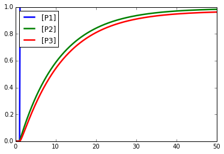

```
<module 'matplotlib.pyplot' from '/usr/lib/pymodules/python2.7/matplotlib/pyplot.pyc'>
```

```python
import numpy
import tellurium as te

antStr = '''
// Input: P1
// Output: P3
dna1: --O1--G1--O2--G2--

P1 -> P1; // Put P1 in the plot

O1 = Vmax*a*P1/(Km + a*P1);
G1: -> P2;
P2 -> ; k*P2

O2 = Vmax*a*P1*P2/(Km + P1 + P2 + a*P1*P2);
G2: -> P3;
P3 -> ; k*P3

Vmax = 0.1; k = 0.1;
Km = 1;
a = 100;
P1 = 0; P2 = 0; P3 = 0;
width = 100

at (time > 1 && time < width + 1): P1 = 1
at (time > width + 1): P1 = 0
'''

r = te.loadAntimonyModel(antStr)
model = r.simulate(0, 50, 500)
te.plotWithLegend(r, numpy.vstack (model))
```

What does C1-FFL do?

In the foregoing:

1. P1 is a step (non-noisy input signal)
2. P3 grows to 1 (filtered output).

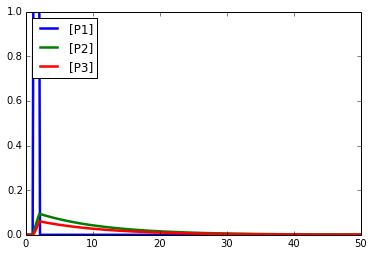

```
<module 'matplotlib.pyplot' from '/usr/lib/pymodules/python2.7/matplotlib/pyplot.pyc'>
```

```python
import numpy
import tellurium as te

antStr = '''
// Input: P1
// Output: P3
dna1: --O1--G1--O2--G2--

P1 -> P1; // Put P1 in the plot

O1 = Vmax*a*P1/(Km + a*P1);
G1: -> P2;
P2 -> ; k*P2

O2 = Vmax*a*P1*P2/(Km + P1 + P2 + a*P1*P2);
G2: -> P3;
P3 -> ; k*P3

Vmax = 0.1; k = 0.1;
Km = 1;
a = 100;
P1 = 0; P2 = 0; P3 = 0;
width = 1

at (time > 1 && time < width + 1): P1 = 1
at (time > width + 1): P1 = 0
'''

r = te.loadAntimonyModel(antStr)
model = r.simulate(0, 50, 500)
te.plotWithLegend(r, numpy.vstack (model))
```

In the foregoing:

1. P1 is an impulse (noisy input signal)
2. P3 stays close to 0 (filtered output).

C1-FFL does noise rejection.

1. P1 is a noisy signal (may have short impulses as well as long steps).
2. P3 is the filtered output.

There are design trade-off for C1-FFL: speed of response vs. noise rejection.

How does this motif handle longer impulses?

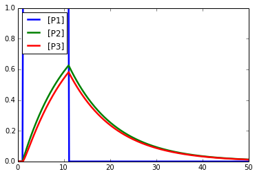

```
<module 'matplotlib.pyplot' from '/usr/lib/pymodules/python2.7/matplotlib/pyplot.pyc'>
```

```python
import numpy
import tellurium as te

antStr = '''
// Input: P1
// Output: P3
dna1: --O1--G1--O2--G2--

P1 -> P1; // Put P1 in the plot

O1 = Vmax*a*P1/(Km + a*P1);
G1: -> P2;
P2 -> ; k*P2

O2 = Vmax*a*P1*P2/(Km + P1 + P2 + a*P1*P2);
G2: -> P3;
P3 -> ; k*P3

Vmax = 0.1; k = 0.1;
Km = 1;
a = 100;
P1 = 0; P2 = 0; P3 = 0;
width = 10

at (time > 1 && time < width + 1): P1 = 1
at (time > width + 1): P1 = 0
'''

r = te.loadAntimonyModel(antStr)
model = r.simulate(0, 50, 500)
te.plotWithLegend(r, numpy.vstack (model))
```

This C1-FFL still filters. But it has a larger (response) than for the shorter input impulses.

*QUESTION*: How can we change the motif to filter longer impulses?

*Hint*: Need to change the kinetics of of the O1 and O2 operators.

*QUESTION*: Do we want slower or faster kinetics?

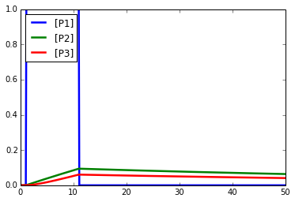

```
<module 'matplotlib.pyplot' from '/usr/lib/pymodules/python2.7/matplotlib/pyplot.pyc'>
```

```python
import numpy
import tellurium as te

antStr = '''
// Input: P1
// Output: P3
dna1: --O1--G1--O2--G2--

P1 -> P1; // Put P1 in the plot

O1 = Vmax*a*P1/(Km + a*P1);
G1: -> P2;
P2 -> ; k*P2

O2 = Vmax*a*P1*P2/(Km + P1 + P2 + a*P1*P2);
G2: -> P3;
P3 -> ; k*P3

Vmax = 0.01; k = 0.01;
Km = 1;
a = 100;
P1 = 0; P2 = 0; P3 = 0;
width = 10

at (time > 1 && time < width + 1): P1 = 1
at (time > width + 1): P1 = 0
'''

r = te.loadAntimonyModel(antStr)
model = r.simulate(0, 50, 500)
te.plotWithLegend(r, numpy.vstack (model))
```

*QUESTION*: Why did we make Vmax and k equal to 0.01?

*QUESTION*: Why did we keep the same ratio between Vmax and k?

Hint: We want to change the kinetics, not the equilibrium values.

*QUESTION*: What happens to the step response with smaller values of Vmax and k?

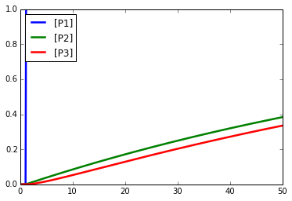

```
<module 'matplotlib.pyplot' from '/usr/lib/pymodules/python2.7/matplotlib/pyplot.pyc'>
```

```python
import numpy
import tellurium as te

antStr = '''
// Input: P1
// Output: P3
dna1: --O1--G1--O2--G2--

P1 -> P1; // Put P1 in the plot

O1 = Vmax*a*P1/(Km + a*P1);
G1: -> P2;
P2 -> ; k*P2

O2 = Vmax*a*P1*P2/(Km + P1 + P2 + a*P1*P2);
G2: -> P3;
P3 -> ; k*P3

Vmax = 0.01; k = 0.01;
Km = 1;
a = 100;
P1 = 0; P2 = 0; P3 = 0;
width = 100

at (time > 1 && time < width + 1): P1 = 1
at (time > width + 1): P1 = 0
'''

r = te.loadAntimonyModel(antStr)
model = r.simulate(0, 50, 500)
te.plotWithLegend(r, numpy.vstack (model))
```

## I1-FFL

[figure not shown]

*QUESTION*: Which of the following changes in the model of I1-FFL vs. C1-FFL

1. Kinetics for Operator 1 (O1).
2. Kinetics for Operator 2 (O2).
3. Kinetics for both O1 and O2.

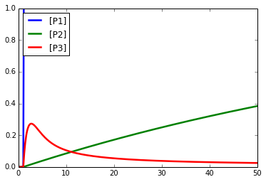

```
<module 'matplotlib.pyplot' from '/usr/lib/pymodules/python2.7/matplotlib/pyplot.pyc'>
```

```python
import numpy
import tellurium as te

antStr = '''
// Input: P1
// Output: P3
dna1: --O1--G1--O2--G2--

P1 -> P1; // Put P1 in the plot

O1 = Vmax1*a*P1/(Km + a*P1);
G1: -> P2;
P2 -> ; k1*P2

O2 = Vmax2*P1/(Km + P1 + P2 + a*P1*P2);
G2: -> P3;
P3 -> ; k2*P3

Vmax1 = 0.01; k1 = 0.01;
Vmax2 = 1; k2 = 1;
Km = 1;
a = 100;
P1 = 0; P2 = 0; P3 = 0;
width = 100

at (time > 1 && time < width + 1): P1 = 1
at (time > width + 1): P1 = 0
'''

r = te.loadAntimonyModel(antStr)
model = r.simulate(0, 50, 500)
te.plotWithLegend(r, numpy.vstack (model))
```

Step input P1 produces an delayed impulse output P3.

*QUESTION*: How can I1-FFL be used?

1. Convert a step input to an impulse output.
2. Recognize concentrations of the input P1.
3. Frequency band filter.